# Bike Benefits

David F. Severski

July 9, 2016

# Background and Motivation

While in the factory store of our local bean-to-bar chocolatier, Theo’s Chocolate, the spouse pointed out a sign that bicyclists could purchase a sticker for their helmet which would give them 50% off one of Theo’s standard bars each time they came in. I’ve long wanted a discount program for local folks coming in so I jumped on this chance. Looking at the sticker, it turned out not to be something specific to Theo’s but a larger program run by [Bicycle Benefits](http://www.bicyclebenefits.org/). What a terrific idea!

An initial glance at the hosted map showed a large number of participating business nearby as well as a long list of cities where member business could be found. The map is a standard Leaflet module with the data available via a simple GET request or two. This stirred my curiosity to explore the data.

# Data Acquisiton and Prepping

A standard set of libraries here. I’m trying to use the `purrr` library more to build familarity with its powerful fuctional idioms.

```r
library(jsonlite)
library(purrr)
library(httr)
library(dplyr)
library(DT)
library(ggplot2)
library(scales)
```

Fetch and clean the data.

```r
# fetch all cities
cities_url <- 'http://www.bicyclebenefits.org/search/cities'
#cities <- fromJSON(content(GET(cities_url), as = "text"), flatten = TRUE)
#save(cities, file = "data/bikebenefits_cities.Rdata")
load("data/bikebenefits_Cities.Rdata")

# fetch the details for a given city
get_biz <- function(city_id, base_url = 'http://www.bicyclebenefits.org/search/members?city_id=')  {
  search_url <- paste0(base_url, city_id)
  dat <- fromJSON(content(GET(search_url), as = "text"), flatten = TRUE)
  dat$members$city_id <- city_id
  dat$city$city_id <- city_id
  return(dat)
}

#dat <- map(cities$id, get_biz)
#save(dat, file = "data/bikebenefits.Rdata")
load("data/bikebenefits.Rdata")

# coerce member business into a dataframe and peel off categories into
# a more normalized table
members <- map(dat, "members") %>% compact %>% bind_rows() %>%
  filter(!is.na(id))
categories <- members %>% distinct(category.id, category.name, category.logo)
categories[categories$category.logo == "","category.logo"] <- NA
members <- members %>% select(-c(category.name, category.logo))

# why do so many places publish the email addresses of their participants?!
members <- select(members, -email)

# coerce the states into a dataframe
states <- map(dat, "city")
states <- do.call(rbind, states) %>% as_data_frame
states$state_name <- map_chr(states$state, "name")
states <- select(states, -state) %>% simplify_all %>% bind_rows
```

# Exploration

Three quick glances of the data at the level of geographic distribution, member business types, and business specifically located in Seattle.

## Geography

```r
members %>% count(city_id, sort = TRUE) %>%
  left_join(cities, by = c("city_id" = "id")) %>%
  select(city_name = name, state.name, n) %>%
  datatable(rownames = NA)
```

| city_name | state.name | n |
| --- | --- | --- |
| Charlotte | North Carolina | 176 |
| Seattle | Washington | 146 |
| Madison | Wisconsin | 128 |
| Minneapolis &amp; St. Paul | Minnesota | 94 |
| Appleton-Fox Cities | Wisconsin | 66 |
| Milwaukee | Wisconsin | 63 |
| Salt Lake City | Utah | 62 |
| Portland | Maine | 51 |
| Boston | Massachusetts | 49 |
| Saratoga Springs | New York | 43 |

[output cut: 107 more lines]

Lots of activity in Charlotte. How does this look at a state level?

```r
members %>% count(city_id, sort = TRUE) %>%
  left_join(cities, by = c("city_id" = "id")) %>%
  select(city_name = name, state.name, n) %>%
  group_by(state.name) %>% tally(n, sort = TRUE) %>%
  datatable(rownames = NA)
```

| state.name | nn |
| --- | --- |
| Wisconsin | 347 |
| North Carolina | 297 |
| Washington | 173 |
| Massachusetts | 140 |
| New York | 109 |
| Minnesota | 99 |
| Maine | 74 |
| Vermont | 68 |
| Utah | 62 |
| Montana | 61 |

[output cut: 16 more lines]

Wow. Wisconsin has a lot going on, while most of Washington’s activity is limited to Seattle.

## Business Type

Produce a table of the relative distribution of member categories per city.

```r
type_breakdown <- members %>% group_by(city_id) %>%
  mutate(city_count = n()) %>% ungroup %>%
  group_by(city_id, category.id) %>%
  summarize(total_per_city = n(),
            cat_pct = n() / max(city_count)) %>% ungroup %>%
  arrange(city_id, desc(cat_pct)) %>%
  left_join(cities, by = c("city_id" = "id")) %>%
  left_join(categories, by = c("category.id" = "category.id"))
type_breakdown %>%
  select(name, category.name, total_per_city, cat_pct) %>%
  datatable(rownames = FALSE) %>% formatPercentage('cat_pct')
```

| name | category.name | total_per_city | cat_pct |
| --- | --- | --- | --- |
| Seattle | Cafes &amp; Coffeeshops | 32 | 0.219178082191781 |
| Seattle | Food &amp; Restaurants | 25 | 0.171232876712329 |
| Seattle | Bars &amp; Breweries | 18 | 0.123287671232877 |
| Seattle | Grocery &amp; Markets | 16 | 0.10958904109589 |
| Seattle | Retail Store | 15 | 0.102739726027397 |
| Seattle | Ice Cream &amp; Sweets | 14 | 0.0958904109589041 |
| Seattle | Bicycle Repair &amp; Sales | 11 | 0.0753424657534247 |
| Seattle | Bakeries | 10 | 0.0684931506849315 |
| Seattle | Other | 3 | 0.0205479452054795 |
| Seattle | Services | 2 | 0.0136986301369863 |

[output cut: 429 more lines]

## Seattle Uber Alles

Finally, a quick view of the Seattle specific data.

```r
members %>% filter(city_id == '3') %>%
  left_join(categories, by = c("category.id" = "category.id")) %>%
  select(-c(starts_with("shipping"), extra_stickers, id, category.id, city_id, category.logo, status)) %>%
  datatable(rownames = FALSE)
```

| address | web | phone | latitude | longitude | name | stickers_available | discount | zipcode | air_pump | category.name |
| --- | --- | --- | --- | --- | --- | --- | --- | --- | --- | --- |
| 1001 Northeast Boat St | http://2ndbaseseattle.com/ | (206)325-2273 | 47.653447800000000 | -122.318117400000000 | 2nd Base-Quality Used Sporting Goods | 1 | 10% Off | 98105 | 1 | Retail Store |
| 1303 N.E. Boat St. | http://aguaverde.com/ | (206)545-8570 | 47.651575200000000 | -122.314348800000000 | Agua Verde | 1 | 10% Off (excl. alcohol) | 98105 | 0 | Food &amp; Restaurants |
| 6400 N.W. 24th Ave | http://greenmarketseattle.com | (206) 784-7594 | 47.675339441947000 | -122.387373447420000 | Ballard Public Green Market | 1 | Free Piece of Fruit! | 98107 | 0 | Grocery &amp; Markets |
| 3507 Fremont Place North | http://9m-unmarked.com | (206) 632-0880 | 47.650845000000000 | -122.350716000000000 | 9 Million in Unmarked Bills | 1 | 10% Off Drinks..no double dipping | 98103 | 0 | Bars &amp; Breweries |
| 5821 Phinney Avenue North | http://alamodeseattle.com | (206) 383-3796 | 47.671719000000000 | -122.354546000000000 | A la Mode Pies | 1 | 10% Off | 98103 | 0 | Ice Cream &amp; Sweets |
| 1521 10th Avenue | https://www.facebook.com/Elliottbaycafe | (206) 436-8482 | 47.614597900000000 | -122.319545900000000 | Elliot Bay Cafe | 0 | 10% Off | 98122 | 0 | Cafes &amp; Coffeeshops |
| 5240 University Way NE | http://www.arayasplace.com/ | (206) 524-4332 | 47.667655000000000 | -122.312699200000000 | Araya's Place | 0 | 10% Off | 98105 | 0 | Food &amp; Restaurants |
| 2253 North 56th Street | http://burgundianbar.com/ | (206) 420-8943 | 47.668885100000000 | -122.331362900000000 | Burgundian | 0 | $1 Off drafts &amp; well drinks | 98103 | 0 | Bars &amp; Breweries |
| 400 N 35th Street | http://brouwerscafe.blogspot.com/ | (206) 267-2437 | 47.651616300000000 | -122.354234400000000 | Brouwer's Cafe | 0 | $1 Off drafts &amp; well drinks | 98103 | 0 | Bars &amp; Breweries |
| 7400 Greenwood Ave North | https://www.facebook.com/bluebirdseattle | (206) 588-6419 | 47.682652700000000 | -122.355046900000000 | Bluebird Ice Cream &amp; Brewery | 0 | 15% Off | 98103 | 0 | Ice Cream &amp; Sweets |

[output cut: 136 more lines]

Show the relative distributions of the types of member business for Seattle and Portland. This may be the only time I’ve ever used sportball colors in a plot. I feel a little dirty.

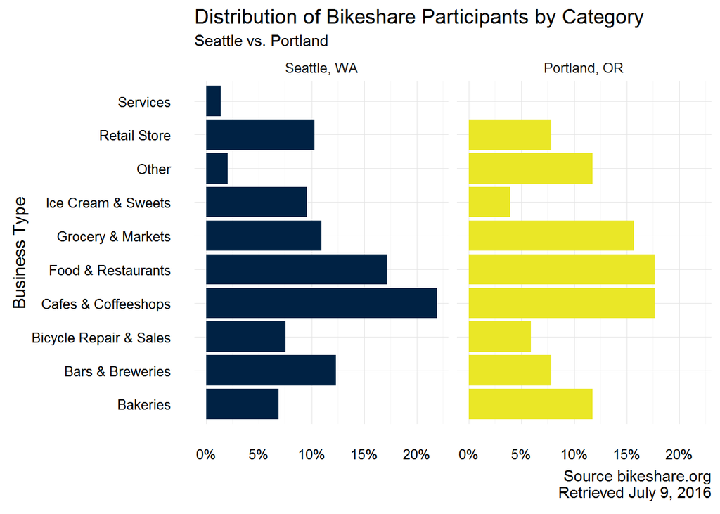

```r
facet_labels <- c(
  '3' = "Seattle, WA",
  '23' = "Portland, OR")
type_breakdown %>% filter(city_id == '3' | city_id == '23') %>%
  mutate(city_id = as.factor(city_id)) %>%
  left_join(categories, by = c("category.id" = "category.id", "category.name" = "category.name")) %>%
  ggplot(., aes(x = category.name, y = cat_pct)) -> gg
gg <- gg + geom_bar(stat = "identity", aes(fill = city_id))
gg <- gg + scale_fill_manual(values = c("#002244", "#EAE727"), guide = FALSE)
gg <- gg + labs(title = "Distribution of Bikeshare Participants by Category",
                subtitle = "Seattle vs. Portland",
                caption = "Source bikeshare.org\nRetrieved July 9, 2016",
                x = "Business Type",
                y = element_blank())
gg <- gg + scale_y_continuous(labels = percent)
gg <- gg + theme_minimal()
gg <- gg + coord_flip()
gg <- gg + facet_grid(. ~ city_id, labeller = as_labeller(facet_labels))
gg
```